# Task 3: Multiple Regression in R

This notebook contains the answers to Task 3:Multiple Regression in R.

```r
library(readr)
library(caret)
library(ggplot2)
library(dplyr)
library(corrplot)
library(gbm)
library(Rcpp)
```

```r
train_df<- read.csv("existingproductattributes2017.csv")#Clients who included their favorite computer brand in the questionaire answers
test_df<- read.csv("newproductattributes2017.csv") #Clients that did not favorite computer brand
train_df
```

| ProductType | ProductNum | Price | x5StarReviews | x4StarReviews | x3StarReviews | x2StarReviews | x1StarReviews | PositiveServiceReview | NegativeServiceReview | Recommendproduct | BestSellersRank | ShippingWeight | ProductDepth | ProductWidth | ProductHeight | ProfitMargin | Volume |
| --- | --- | --- | --- | --- | --- | --- | --- | --- | --- | --- | --- | --- | --- | --- | --- | --- | --- |
| PC | 101 | 949.00 | 3 | 3 | 2 | 0 | 0 | 2 | 0 | 0.9 | 1967 | 25.80 | 23.94 | 6.62 | 16.89 | 0.15 | 12 |
| PC | 102 | 2249.99 | 2 | 1 | 0 | 0 | 0 | 1 | 0 | 0.9 | 4806 | 50.00 | 35.00 | 31.75 | 19.00 | 0.25 | 8 |
| PC | 103 | 399.00 | 3 | 0 | 0 | 0 | 0 | 1 | 0 | 0.9 | 12076 | 17.40 | 10.50 | 8.30 | 10.20 | 0.08 | 12 |
| Laptop | 104 | 409.99 | 49 | 19 | 8 | 3 | 9 | 7 | 8 | 0.8 | 109 | 5.70 | 15.00 | 9.90 | 1.30 | 0.08 | 196 |
| Laptop | 105 | 1079.99 | 58 | 31 | 11 | 7 | 36 | 7 | 20 | 0.7 | 268 | 7.00 | 12.90 | 0.30 | 8.90 | 0.09 | 232 |
| Accessories | 106 | 114.22 | 83 | 30 | 10 | 9 | 40 | 12 | 5 | 0.3 | 64 | 1.60 | 5.80 | 4.00 | 1.00 | 0.05 | 332 |
| Accessories | 107 | 379.99 | 11 | 3 | 0 | 0 | 1 | 3 | 0 | 0.9 | NA | 7.30 | 6.70 | 10.30 | 11.50 | 0.05 | 44 |
| Accessories | 108 | 65.29 | 33 | 19 | 12 | 5 | 9 | 5 | 3 | 0.7 | 2 | 12.00 | 7.90 | 6.70 | 2.20 | 0.05 | 132 |
| Accessories | 109 | 119.99 | 16 | 9 | 2 | 0 | 2 | 2 | 1 | 0.8 | NA | 1.80 | 10.60 | 9.40 | 4.70 | 0.05 | 64 |
| Accessories | 110 | 16.99 | 10 | 1 | 1 | 0 | 0 | 2 | 0 | 0.9 | 18 | 0.75 | 10.70 | 13.10 | 0.60 | 0.05 | 40 |

[output cut: 70 more lines]

```r
test_df
```

| ProductType | ProductNum | Price | x5StarReviews | x4StarReviews | x3StarReviews | x2StarReviews | x1StarReviews | PositiveServiceReview | NegativeServiceReview | Recommendproduct | BestSellersRank | ShippingWeight | ProductDepth | ProductWidth | ProductHeight | ProfitMargin | Volume |
| --- | --- | --- | --- | --- | --- | --- | --- | --- | --- | --- | --- | --- | --- | --- | --- | --- | --- |
| PC | 171 | 699.00 | 96 | 26 | 14 | 14 | 25 | 12 | 3 | 0.7 | 2498 | 19.90 | 20.63 | 19.25 | 8.39 | 0.25 | 0 |
| PC | 172 | 860.00 | 51 | 11 | 10 | 10 | 21 | 7 | 5 | 0.6 | 490 | 27.00 | 21.89 | 27.01 | 9.13 | 0.20 | 0 |
| Laptop | 173 | 1199.00 | 74 | 10 | 3 | 3 | 11 | 11 | 5 | 0.8 | 111 | 6.60 | 8.94 | 12.80 | 0.68 | 0.10 | 0 |
| Laptop | 175 | 1199.00 | 7 | 2 | 1 | 1 | 1 | 2 | 1 | 0.6 | 4446 | 13.00 | 16.30 | 10.80 | 1.40 | 0.15 | 0 |
| Laptop | 176 | 1999.00 | 1 | 1 | 1 | 3 | 0 | 0 | 1 | 0.3 | 2820 | 11.60 | 16.81 | 10.90 | 0.88 | 0.23 | 0 |
| Netbook | 178 | 399.99 | 19 | 8 | 4 | 1 | 10 | 2 | 4 | 0.6 | 4140 | 5.80 | 8.43 | 11.42 | 1.20 | 0.08 | 0 |
| Netbook | 180 | 329.00 | 312 | 112 | 28 | 31 | 47 | 28 | 16 | 0.7 | 2699 | 4.60 | 10.17 | 7.28 | 0.95 | 0.09 | 0 |
| Netbook | 181 | 439.00 | 23 | 18 | 7 | 22 | 18 | 5 | 16 | 0.4 | 1704 | 4.80 | 8.00 | 11.70 | 1.50 | 0.11 | 0 |
| Netbook | 183 | 330.00 | 3 | 4 | 0 | 1 | 0 | 1 | 0 | 0.7 | 5128 | 4.30 | 7.40 | 10.40 | 0.97 | 0.09 | 0 |
| Tablet | 186 | 629.00 | 296 | 66 | 30 | 21 | 36 | 28 | 9 | 0.8 | 34 | 3.00 | 7.31 | 9.50 | 0.37 | 0.10 | 0 |

[output cut: 14 more lines]

These are the two datasets to be used for this task. It’s worth noting that the column “volume” in the test_df has been filled with zeroes (as default). Therefore this column is meaningless as it is and should not be used directly.

*Understand the data:*

```r
#print("List your attributes within your data set.")
#attributes(train_df)  # Too long
print("Prints the min, max, mean, median, and quartiles of each attribute.")
```

```
[1] "Prints the min, max, mean, median, and quartiles of each attribute."
```

```r
summary(train_df)
```

```
 ProductType          ProductNum        Price         x5StarReviews    x4StarReviews    x3StarReviews    x2StarReviews
 Length:80          Min.   :101.0   Min.   :   3.60   Min.   :   0.0   Min.   :  0.00   Min.   :  0.00   Min.   :  0.00
 Class :character   1st Qu.:120.8   1st Qu.:  52.66   1st Qu.:  10.0   1st Qu.:  2.75   1st Qu.:  2.00   1st Qu.:  1.00
 Mode  :character   Median :140.5   Median : 132.72   Median :  50.0   Median : 22.00   Median :  7.00   Median :  3.00
                    Mean   :142.6   Mean   : 247.25   Mean   : 176.2   Mean   : 40.20   Mean   : 14.79   Mean   : 13.79
                    3rd Qu.:160.2   3rd Qu.: 352.49   3rd Qu.: 306.5   3rd Qu.: 33.00   3rd Qu.: 11.25   3rd Qu.:  7.00
                    Max.   :200.0   Max.   :2249.99   Max.   :2801.0   Max.   :431.00   Max.   :162.00   Max.   :370.00

 x1StarReviews     PositiveServiceReview NegativeServiceReview Recommendproduct BestSellersRank ShippingWeight     ProductDepth
 Min.   :   0.00   Min.   :  0.00        Min.   :  0.000       Min.   :0.100    Min.   :    1   Min.   : 0.0100   Min.   :  0.000
 1st Qu.:   2.00   1st Qu.:  2.00        1st Qu.:  1.000       1st Qu.:0.700    1st Qu.:    7   1st Qu.: 0.5125   1st Qu.:  4.775
 Median :   8.50   Median :  5.50        Median :  3.000       Median :0.800    Median :   27   Median : 2.1000   Median :  7.950
 Mean   :  37.67   Mean   : 51.75        Mean   :  6.225       Mean   :0.745    Mean   : 1126   Mean   : 9.6681   Mean   : 14.425
 3rd Qu.:  15.25   3rd Qu.: 42.00        3rd Qu.:  6.250       3rd Qu.:0.900    3rd Qu.:  281   3rd Qu.:11.2050   3rd Qu.: 15.025
 Max.   :1654.00   Max.   :536.00        Max.   :112.000       Max.   :1.000    Max.   :17502   Max.   :63.0000   Max.   :300.000
                                                                                NA's   :15
  ProductWidth    ProductHeight     ProfitMargin        Volume
 Min.   : 0.000   Min.   : 0.000   Min.   :0.0500   Min.   :    0
 1st Qu.: 1.750   1st Qu.: 0.400   1st Qu.:0.0500   1st Qu.:   40
 Median : 6.800   Median : 3.950   Median :0.1200   Median :  200
 Mean   : 7.819   Mean   : 6.259   Mean   :0.1545   Mean   :  705
 3rd Qu.:11.275   3rd Qu.:10.300   3rd Qu.:0.2000   3rd Qu.: 1226
 Max.   :31.750   Max.   :25.800   Max.   :0.4000   Max.   :11204
```

```r
print("Displays the structure of your data set.")
```

```
[1] "Displays the structure of your data set."
```

```r
str(train_df)
```

```
'data.frame':   80 obs. of  18 variables:
 $ ProductType          : chr  "PC" "PC" "PC" "Laptop" ...
 $ ProductNum           : int  101 102 103 104 105 106 107 108 109 110 ...
 $ Price                : num  949 2250 399 410 1080 ...
 $ x5StarReviews        : int  3 2 3 49 58 83 11 33 16 10 ...
 $ x4StarReviews        : int  3 1 0 19 31 30 3 19 9 1 ...
 $ x3StarReviews        : int  2 0 0 8 11 10 0 12 2 1 ...
 $ x2StarReviews        : int  0 0 0 3 7 9 0 5 0 0 ...
 $ x1StarReviews        : int  0 0 0 9 36 40 1 9 2 0 ...
 $ PositiveServiceReview: int  2 1 1 7 7 12 3 5 2 2 ...
 $ NegativeServiceReview: int  0 0 0 8 20 5 0 3 1 0 ...
 $ Recommendproduct     : num  0.9 0.9 0.9 0.8 0.7 0.3 0.9 0.7 0.8 0.9 ...
 $ BestSellersRank      : int  1967 4806 12076 109 268 64 NA 2 NA 18 ...
 $ ShippingWeight       : num  25.8 50 17.4 5.7 7 1.6 7.3 12 1.8 0.75 ...
 $ ProductDepth         : num  23.9 35 10.5 15 12.9 ...
 $ ProductWidth         : num  6.62 31.75 8.3 9.9 0.3 ...
 $ ProductHeight        : num  16.9 19 10.2 1.3 8.9 ...
 $ ProfitMargin         : num  0.15 0.25 0.08 0.08 0.09 0.05 0.05 0.05 0.05 0.05 ...
 $ Volume               : int  12 8 12 196 232 332 44 132 64 40 ...
```

```r
print("Names your attributes within your data set.")
```

```
[1] "Names your attributes within your data set."
```

```r
names(train_df)
```

```
 [1] "ProductType"           "ProductNum"            "Price"                 "x5StarReviews"         "x4StarReviews"
 [6] "x3StarReviews"         "x2StarReviews"         "x1StarReviews"         "PositiveServiceReview" "NegativeServiceReview"
[11] "Recommendproduct"      "BestSellersRank"       "ShippingWeight"        "ProductDepth"          "ProductWidth"
[16] "ProductHeight"         "ProfitMargin"          "Volume"
```

```r
#print("Will print out the instances within that particular column in your data set.")
#train_df$salary # Too long
#train_df$age  # Too long
```

```r
print("Prints the min, max, mean, median, and quartiles of each attribute.")
```

```
[1] "Prints the min, max, mean, median, and quartiles of each attribute."
```

```r
summary(test_df)
```

```
 ProductType          ProductNum        Price        x5StarReviews     x4StarReviews    x3StarReviews    x2StarReviews
 Length:24          Min.   :171.0   Min.   :   8.5   Min.   :   0.00   Min.   :  0.00   Min.   :  0.00   Min.   :  0.00
 Class :character   1st Qu.:179.5   1st Qu.: 130.0   1st Qu.:  16.00   1st Qu.:  2.00   1st Qu.:  1.75   1st Qu.:  1.00
 Mode  :character   Median :193.5   Median : 275.0   Median :  46.00   Median : 10.50   Median :  4.50   Median :  4.00
                    Mean   :219.5   Mean   : 425.6   Mean   : 178.50   Mean   : 48.04   Mean   : 21.92   Mean   : 17.50
                    3rd Qu.:301.2   3rd Qu.: 486.5   3rd Qu.:  99.25   3rd Qu.: 26.00   3rd Qu.: 16.75   3rd Qu.: 20.25
                    Max.   :307.0   Max.   :1999.0   Max.   :1525.00   Max.   :437.00   Max.   :224.00   Max.   :160.00
 x1StarReviews    PositiveServiceReview NegativeServiceReview Recommendproduct BestSellersRank    ShippingWeight    ProductDepth
 Min.   :  0.00   Min.   : 0.00         Min.   : 0.000        Min.   :0.3000   Min.   :    1.00   Min.   : 0.200   Min.   : 0.000
 1st Qu.:  1.75   1st Qu.: 2.00         1st Qu.: 1.000        1st Qu.:0.6000   1st Qu.:   93.25   1st Qu.: 0.900   1st Qu.: 5.225
 Median : 13.00   Median : 5.00         Median : 3.500        Median :0.7000   Median :  750.50   Median : 4.450   Median : 8.000
 Mean   : 27.58   Mean   :13.46         Mean   : 5.667        Mean   :0.6708   Mean   : 3957.62   Mean   : 7.802   Mean   : 9.094
 3rd Qu.: 35.25   3rd Qu.:12.50         3rd Qu.: 7.500        3rd Qu.:0.8000   3rd Qu.: 3150.00   3rd Qu.: 9.575   3rd Qu.:11.425
 Max.   :247.00   Max.   :90.00         Max.   :23.000        Max.   :1.0000   Max.   :44465.00   Max.   :42.000   Max.   :21.890
  ProductWidth    ProductHeight     ProfitMargin        Volume
 Min.   : 0.000   Min.   : 0.000   Min.   :0.0500   Min.   :0
 1st Qu.: 5.832   1st Qu.: 0.400   1st Qu.:0.0975   1st Qu.:0
 Median : 9.950   Median : 0.985   Median :0.1150   Median :0
 Mean   :10.408   Mean   : 3.541   Mean   :0.1817   Mean   :0
 3rd Qu.:12.875   3rd Qu.: 2.888   3rd Qu.:0.2000   3rd Qu.:0
 Max.   :27.010   Max.   :25.800   Max.   :0.9000   Max.   :0
```

```r
print("Displays the structure of your data set.")
```

```
[1] "Displays the structure of your data set."
```

```r
str(test_df)
```

```
'data.frame':   24 obs. of  18 variables:
 $ ProductType          : chr  "PC" "PC" "Laptop" "Laptop" ...
 $ ProductNum           : int  171 172 173 175 176 178 180 181 183 186 ...
 $ Price                : num  699 860 1199 1199 1999 ...
 $ x5StarReviews        : int  96 51 74 7 1 19 312 23 3 296 ...
 $ x4StarReviews        : int  26 11 10 2 1 8 112 18 4 66 ...
 $ x3StarReviews        : int  14 10 3 1 1 4 28 7 0 30 ...
 $ x2StarReviews        : int  14 10 3 1 3 1 31 22 1 21 ...
 $ x1StarReviews        : int  25 21 11 1 0 10 47 18 0 36 ...
 $ PositiveServiceReview: int  12 7 11 2 0 2 28 5 1 28 ...
 $ NegativeServiceReview: int  3 5 5 1 1 4 16 16 0 9 ...
 $ Recommendproduct     : num  0.7 0.6 0.8 0.6 0.3 0.6 0.7 0.4 0.7 0.8 ...
 $ BestSellersRank      : int  2498 490 111 4446 2820 4140 2699 1704 5128 34 ...
 $ ShippingWeight       : num  19.9 27 6.6 13 11.6 5.8 4.6 4.8 4.3 3 ...
 $ ProductDepth         : num  20.63 21.89 8.94 16.3 16.81 ...
 $ ProductWidth         : num  19.2 27 12.8 10.8 10.9 ...
 $ ProductHeight        : num  8.39 9.13 0.68 1.4 0.88 1.2 0.95 1.5 0.97 0.37 ...
 $ ProfitMargin         : num  0.25 0.2 0.1 0.15 0.23 0.08 0.09 0.11 0.09 0.1 ...
 $ Volume               : int  0 0 0 0 0 0 0 0 0 0 ...
```

```r
print("Names your attributes within your data set.")
```

```
[1] "Names your attributes within your data set."
```

```r
names(test_df)
```

```
 [1] "ProductType"           "ProductNum"            "Price"                 "x5StarReviews"         "x4StarReviews"
 [6] "x3StarReviews"         "x2StarReviews"         "x1StarReviews"         "PositiveServiceReview" "NegativeServiceReview"
[11] "Recommendproduct"      "BestSellersRank"       "ShippingWeight"        "ProductDepth"          "ProductWidth"
[16] "ProductHeight"         "ProfitMargin"          "Volume"
```

```r
sapply(train_df, typeof)
```

```
          ProductType            ProductNum                 Price         x5StarReviews         x4StarReviews         x3StarReviews
          "character"             "integer"              "double"             "integer"             "integer"             "integer"
        x2StarReviews         x1StarReviews PositiveServiceReview NegativeServiceReview      Recommendproduct       BestSellersRank
            "integer"             "integer"             "integer"             "integer"              "double"             "integer"
       ShippingWeight          ProductDepth          ProductWidth         ProductHeight          ProfitMargin                Volume
             "double"              "double"              "double"              "double"              "double"             "integer"
```

```r
sapply(train_df, typeof) == sapply(test_df, typeof)
```

```
          ProductType            ProductNum                 Price         x5StarReviews         x4StarReviews         x3StarReviews
                 TRUE                  TRUE                  TRUE                  TRUE                  TRUE                  TRUE
        x2StarReviews         x1StarReviews PositiveServiceReview NegativeServiceReview      Recommendproduct       BestSellersRank
                 TRUE                  TRUE                  TRUE                  TRUE                  TRUE                  TRUE
       ShippingWeight          ProductDepth          ProductWidth         ProductHeight          ProfitMargin                Volume
                 TRUE                  TRUE                  TRUE                  TRUE                  TRUE                  TRUE
```

The column types coincide, but the variable ProductType is of character type. Therefore, I will dummify this column into a binary One hot encoding with caret. The remaining columns are of numerical type so no further adjustments needed here.

```r
#Convert categorical columns into factors to indicate that these columns contain a limited number of unique values.
length(table(train_df$ProductType))
```

```
[1] 12
```

```r
# Rewrite the train_df with the dummy variables:
newDataFrame <- dummyVars(" ~ .", data = train_df)
train_df <- data.frame(predict(newDataFrame, newdata = train_df))
train_df
```

|  | ProductTypeAccessories | ProductTypeDisplay | ProductTypeExtendedWarranty | ProductTypeGameConsole | ProductTypeLaptop | ProductTypeNetbook | ProductTypePC | ProductTypePrinter | ProductTypePrinterSupplies | ProductTypeSmartphone | ProductTypeSoftware | ProductTypeTablet | ProductNum | Price | x5StarReviews | x4StarReviews | x3StarReviews | x2StarReviews | x1StarReviews | PositiveServiceReview | NegativeServiceReview | Recommendproduct | BestSellersRank | ShippingWeight | ProductDepth | ProductWidth | ProductHeight | ProfitMargin | Volume |
| --- | --- | --- | --- | --- | --- | --- | --- | --- | --- | --- | --- | --- | --- | --- | --- | --- | --- | --- | --- | --- | --- | --- | --- | --- | --- | --- | --- | --- | --- |
| 1 | 0 | 0 | 0 | 0 | 0 | 0 | 1 | 0 | 0 | 0 | 0 | 0 | 101 | 949.00 | 3 | 3 | 2 | 0 | 0 | 2 | 0 | 0.9 | 1967 | 25.80 | 23.94 | 6.62 | 16.89 | 0.15 | 12 |
| 2 | 0 | 0 | 0 | 0 | 0 | 0 | 1 | 0 | 0 | 0 | 0 | 0 | 102 | 2249.99 | 2 | 1 | 0 | 0 | 0 | 1 | 0 | 0.9 | 4806 | 50.00 | 35.00 | 31.75 | 19.00 | 0.25 | 8 |
| 3 | 0 | 0 | 0 | 0 | 0 | 0 | 1 | 0 | 0 | 0 | 0 | 0 | 103 | 399.00 | 3 | 0 | 0 | 0 | 0 | 1 | 0 | 0.9 | 12076 | 17.40 | 10.50 | 8.30 | 10.20 | 0.08 | 12 |
| 4 | 0 | 0 | 0 | 0 | 1 | 0 | 0 | 0 | 0 | 0 | 0 | 0 | 104 | 409.99 | 49 | 19 | 8 | 3 | 9 | 7 | 8 | 0.8 | 109 | 5.70 | 15.00 | 9.90 | 1.30 | 0.08 | 196 |
| 5 | 0 | 0 | 0 | 0 | 1 | 0 | 0 | 0 | 0 | 0 | 0 | 0 | 105 | 1079.99 | 58 | 31 | 11 | 7 | 36 | 7 | 20 | 0.7 | 268 | 7.00 | 12.90 | 0.30 | 8.90 | 0.09 | 232 |
| 6 | 1 | 0 | 0 | 0 | 0 | 0 | 0 | 0 | 0 | 0 | 0 | 0 | 106 | 114.22 | 83 | 30 | 10 | 9 | 40 | 12 | 5 | 0.3 | 64 | 1.60 | 5.80 | 4.00 | 1.00 | 0.05 | 332 |
| 7 | 1 | 0 | 0 | 0 | 0 | 0 | 0 | 0 | 0 | 0 | 0 | 0 | 107 | 379.99 | 11 | 3 | 0 | 0 | 1 | 3 | 0 | 0.9 | NA | 7.30 | 6.70 | 10.30 | 11.50 | 0.05 | 44 |
| 8 | 1 | 0 | 0 | 0 | 0 | 0 | 0 | 0 | 0 | 0 | 0 | 0 | 108 | 65.29 | 33 | 19 | 12 | 5 | 9 | 5 | 3 | 0.7 | 2 | 12.00 | 7.90 | 6.70 | 2.20 | 0.05 | 132 |
| 9 | 1 | 0 | 0 | 0 | 0 | 0 | 0 | 0 | 0 | 0 | 0 | 0 | 109 | 119.99 | 16 | 9 | 2 | 0 | 2 | 2 | 1 | 0.8 | NA | 1.80 | 10.60 | 9.40 | 4.70 | 0.05 | 64 |
| 10 | 1 | 0 | 0 | 0 | 0 | 0 | 0 | 0 | 0 | 0 | 0 | 0 | 110 | 16.99 | 10 | 1 | 1 | 0 | 0 | 2 | 0 | 0.9 | 18 | 0.75 | 10.70 | 13.10 | 0.60 | 0.05 | 40 |

[output cut: 70 more lines]

```r
NA
```

The column ProductType has 12 possible values. As we previously had 18 columns in total, after dummifying the data both datasets will contain (18-1(removal of original column)+12=) 29 columns, which is what we have.

Now I will perform the same process on the test dataset so both datasets remain identical and ready to use:

```r
# Rewrite the train_df with the dummy variables:
newDataFrame2 <- dummyVars(" ~ .", data = test_df)
test_df <- data.frame(predict(newDataFrame2, newdata = test_df))
test_df
```

|  | ProductTypeAccessories | ProductTypeDisplay | ProductTypeExtendedWarranty | ProductTypeGameConsole | ProductTypeLaptop | ProductTypeNetbook | ProductTypePC | ProductTypePrinter | ProductTypePrinterSupplies | ProductTypeSmartphone | ProductTypeSoftware | ProductTypeTablet | ProductNum | Price | x5StarReviews | x4StarReviews | x3StarReviews | x2StarReviews | x1StarReviews | PositiveServiceReview | NegativeServiceReview | Recommendproduct | BestSellersRank | ShippingWeight | ProductDepth | ProductWidth | ProductHeight | ProfitMargin | Volume |
| --- | --- | --- | --- | --- | --- | --- | --- | --- | --- | --- | --- | --- | --- | --- | --- | --- | --- | --- | --- | --- | --- | --- | --- | --- | --- | --- | --- | --- | --- |
| 1 | 0 | 0 | 0 | 0 | 0 | 0 | 1 | 0 | 0 | 0 | 0 | 0 | 171 | 699.00 | 96 | 26 | 14 | 14 | 25 | 12 | 3 | 0.7 | 2498 | 19.90 | 20.63 | 19.25 | 8.39 | 0.25 | 0 |
| 2 | 0 | 0 | 0 | 0 | 0 | 0 | 1 | 0 | 0 | 0 | 0 | 0 | 172 | 860.00 | 51 | 11 | 10 | 10 | 21 | 7 | 5 | 0.6 | 490 | 27.00 | 21.89 | 27.01 | 9.13 | 0.20 | 0 |
| 3 | 0 | 0 | 0 | 0 | 1 | 0 | 0 | 0 | 0 | 0 | 0 | 0 | 173 | 1199.00 | 74 | 10 | 3 | 3 | 11 | 11 | 5 | 0.8 | 111 | 6.60 | 8.94 | 12.80 | 0.68 | 0.10 | 0 |
| 4 | 0 | 0 | 0 | 0 | 1 | 0 | 0 | 0 | 0 | 0 | 0 | 0 | 175 | 1199.00 | 7 | 2 | 1 | 1 | 1 | 2 | 1 | 0.6 | 4446 | 13.00 | 16.30 | 10.80 | 1.40 | 0.15 | 0 |
| 5 | 0 | 0 | 0 | 0 | 1 | 0 | 0 | 0 | 0 | 0 | 0 | 0 | 176 | 1999.00 | 1 | 1 | 1 | 3 | 0 | 0 | 1 | 0.3 | 2820 | 11.60 | 16.81 | 10.90 | 0.88 | 0.23 | 0 |
| 6 | 0 | 0 | 0 | 0 | 0 | 1 | 0 | 0 | 0 | 0 | 0 | 0 | 178 | 399.99 | 19 | 8 | 4 | 1 | 10 | 2 | 4 | 0.6 | 4140 | 5.80 | 8.43 | 11.42 | 1.20 | 0.08 | 0 |
| 7 | 0 | 0 | 0 | 0 | 0 | 1 | 0 | 0 | 0 | 0 | 0 | 0 | 180 | 329.00 | 312 | 112 | 28 | 31 | 47 | 28 | 16 | 0.7 | 2699 | 4.60 | 10.17 | 7.28 | 0.95 | 0.09 | 0 |
| 8 | 0 | 0 | 0 | 0 | 0 | 1 | 0 | 0 | 0 | 0 | 0 | 0 | 181 | 439.00 | 23 | 18 | 7 | 22 | 18 | 5 | 16 | 0.4 | 1704 | 4.80 | 8.00 | 11.70 | 1.50 | 0.11 | 0 |
| 9 | 0 | 0 | 0 | 0 | 0 | 1 | 0 | 0 | 0 | 0 | 0 | 0 | 183 | 330.00 | 3 | 4 | 0 | 1 | 0 | 1 | 0 | 0.7 | 5128 | 4.30 | 7.40 | 10.40 | 0.97 | 0.09 | 0 |
| 10 | 0 | 0 | 0 | 0 | 0 | 0 | 0 | 0 | 0 | 0 | 0 | 1 | 186 | 629.00 | 296 | 66 | 30 | 21 | 36 | 28 | 9 | 0.8 | 34 | 3.00 | 7.31 | 9.50 | 0.37 | 0.10 | 0 |

[output cut: 14 more lines]

The same 29 columns are verified here.

```r
any(is.na(train_df))
```

```
[1] TRUE
```

```r
any(is.na(test_df))
```

```
[1] FALSE
```

The train_df has null values. Investigate:

```r
names(which(colSums(is.na(train_df)) > 0))
```

```
[1] "BestSellersRank"
```

```r
train_df$BestSellersRank
```

```
 [1]  1967  4806 12076   109   268    64    NA     2    NA    18    NA     7    NA     6    NA   927   661     1    NA   110    NA
[22]     1   398   150   281     2    60    29 17502    NA    NA     5    11    16     7     7     7     7     7     7     7    NA
[43]  1473    17     9    22    11     3    17    30   100     3    22    27    27     1     8    50    48     6    11    76    NA
[64]    NA    NA    NA    10    69    NA  6295   134   829   215     4   544   720  5742  2723 14086   352
```

As can be seen above the column BestSellersRank in the train_df has got quite a few Null values. According to the plan of attack I should just ignore the variables with nulls. (Otherwise, I would address these nulls by replacing them with whatever one should do when correcting ranking variables. Out of the top of my head, I would quite possibly use the median as replacement value. This way, the replaced nulls would be pretty neutral when looking at this variable as a whole)

```r
train_df$BestSellersRank <- NULL
train_df
```

|  | ProductTypeAccessories | ProductTypeDisplay | ProductTypeExtendedWarranty | ProductTypeGameConsole | ProductTypeLaptop | ProductTypeNetbook | ProductTypePC | ProductTypePrinter | ProductTypePrinterSupplies | ProductTypeSmartphone | ProductTypeSoftware | ProductTypeTablet | ProductNum | Price | x5StarReviews | x4StarReviews | x3StarReviews | x2StarReviews | x1StarReviews | PositiveServiceReview | NegativeServiceReview | Recommendproduct | ShippingWeight | ProductDepth | ProductWidth | ProductHeight | ProfitMargin | Volume |
| --- | --- | --- | --- | --- | --- | --- | --- | --- | --- | --- | --- | --- | --- | --- | --- | --- | --- | --- | --- | --- | --- | --- | --- | --- | --- | --- | --- | --- |
| 1 | 0 | 0 | 0 | 0 | 0 | 0 | 1 | 0 | 0 | 0 | 0 | 0 | 101 | 949.00 | 3 | 3 | 2 | 0 | 0 | 2 | 0 | 0.9 | 25.80 | 23.94 | 6.62 | 16.89 | 0.15 | 12 |
| 2 | 0 | 0 | 0 | 0 | 0 | 0 | 1 | 0 | 0 | 0 | 0 | 0 | 102 | 2249.99 | 2 | 1 | 0 | 0 | 0 | 1 | 0 | 0.9 | 50.00 | 35.00 | 31.75 | 19.00 | 0.25 | 8 |
| 3 | 0 | 0 | 0 | 0 | 0 | 0 | 1 | 0 | 0 | 0 | 0 | 0 | 103 | 399.00 | 3 | 0 | 0 | 0 | 0 | 1 | 0 | 0.9 | 17.40 | 10.50 | 8.30 | 10.20 | 0.08 | 12 |
| 4 | 0 | 0 | 0 | 0 | 1 | 0 | 0 | 0 | 0 | 0 | 0 | 0 | 104 | 409.99 | 49 | 19 | 8 | 3 | 9 | 7 | 8 | 0.8 | 5.70 | 15.00 | 9.90 | 1.30 | 0.08 | 196 |
| 5 | 0 | 0 | 0 | 0 | 1 | 0 | 0 | 0 | 0 | 0 | 0 | 0 | 105 | 1079.99 | 58 | 31 | 11 | 7 | 36 | 7 | 20 | 0.7 | 7.00 | 12.90 | 0.30 | 8.90 | 0.09 | 232 |
| 6 | 1 | 0 | 0 | 0 | 0 | 0 | 0 | 0 | 0 | 0 | 0 | 0 | 106 | 114.22 | 83 | 30 | 10 | 9 | 40 | 12 | 5 | 0.3 | 1.60 | 5.80 | 4.00 | 1.00 | 0.05 | 332 |
| 7 | 1 | 0 | 0 | 0 | 0 | 0 | 0 | 0 | 0 | 0 | 0 | 0 | 107 | 379.99 | 11 | 3 | 0 | 0 | 1 | 3 | 0 | 0.9 | 7.30 | 6.70 | 10.30 | 11.50 | 0.05 | 44 |
| 8 | 1 | 0 | 0 | 0 | 0 | 0 | 0 | 0 | 0 | 0 | 0 | 0 | 108 | 65.29 | 33 | 19 | 12 | 5 | 9 | 5 | 3 | 0.7 | 12.00 | 7.90 | 6.70 | 2.20 | 0.05 | 132 |
| 9 | 1 | 0 | 0 | 0 | 0 | 0 | 0 | 0 | 0 | 0 | 0 | 0 | 109 | 119.99 | 16 | 9 | 2 | 0 | 2 | 2 | 1 | 0.8 | 1.80 | 10.60 | 9.40 | 4.70 | 0.05 | 64 |
| 10 | 1 | 0 | 0 | 0 | 0 | 0 | 0 | 0 | 0 | 0 | 0 | 0 | 110 | 16.99 | 10 | 1 | 1 | 0 | 0 | 2 | 0 | 0.9 | 0.75 | 10.70 | 13.10 | 0.60 | 0.05 | 40 |

[output cut: 70 more lines]

```r
test_df$BestSellersRank <- NULL
test_df
```

|  | ProductTypeAccessories | ProductTypeDisplay | ProductTypeExtendedWarranty | ProductTypeGameConsole | ProductTypeLaptop | ProductTypeNetbook | ProductTypePC | ProductTypePrinter | ProductTypePrinterSupplies | ProductTypeSmartphone | ProductTypeSoftware | ProductTypeTablet | ProductNum | Price | x5StarReviews | x4StarReviews | x3StarReviews | x2StarReviews | x1StarReviews | PositiveServiceReview | NegativeServiceReview | Recommendproduct | ShippingWeight | ProductDepth | ProductWidth | ProductHeight | ProfitMargin | Volume |
| --- | --- | --- | --- | --- | --- | --- | --- | --- | --- | --- | --- | --- | --- | --- | --- | --- | --- | --- | --- | --- | --- | --- | --- | --- | --- | --- | --- | --- |
| 1 | 0 | 0 | 0 | 0 | 0 | 0 | 1 | 0 | 0 | 0 | 0 | 0 | 171 | 699.00 | 96 | 26 | 14 | 14 | 25 | 12 | 3 | 0.7 | 19.90 | 20.63 | 19.25 | 8.39 | 0.25 | 0 |
| 2 | 0 | 0 | 0 | 0 | 0 | 0 | 1 | 0 | 0 | 0 | 0 | 0 | 172 | 860.00 | 51 | 11 | 10 | 10 | 21 | 7 | 5 | 0.6 | 27.00 | 21.89 | 27.01 | 9.13 | 0.20 | 0 |
| 3 | 0 | 0 | 0 | 0 | 1 | 0 | 0 | 0 | 0 | 0 | 0 | 0 | 173 | 1199.00 | 74 | 10 | 3 | 3 | 11 | 11 | 5 | 0.8 | 6.60 | 8.94 | 12.80 | 0.68 | 0.10 | 0 |
| 4 | 0 | 0 | 0 | 0 | 1 | 0 | 0 | 0 | 0 | 0 | 0 | 0 | 175 | 1199.00 | 7 | 2 | 1 | 1 | 1 | 2 | 1 | 0.6 | 13.00 | 16.30 | 10.80 | 1.40 | 0.15 | 0 |
| 5 | 0 | 0 | 0 | 0 | 1 | 0 | 0 | 0 | 0 | 0 | 0 | 0 | 176 | 1999.00 | 1 | 1 | 1 | 3 | 0 | 0 | 1 | 0.3 | 11.60 | 16.81 | 10.90 | 0.88 | 0.23 | 0 |
| 6 | 0 | 0 | 0 | 0 | 0 | 1 | 0 | 0 | 0 | 0 | 0 | 0 | 178 | 399.99 | 19 | 8 | 4 | 1 | 10 | 2 | 4 | 0.6 | 5.80 | 8.43 | 11.42 | 1.20 | 0.08 | 0 |
| 7 | 0 | 0 | 0 | 0 | 0 | 1 | 0 | 0 | 0 | 0 | 0 | 0 | 180 | 329.00 | 312 | 112 | 28 | 31 | 47 | 28 | 16 | 0.7 | 4.60 | 10.17 | 7.28 | 0.95 | 0.09 | 0 |
| 8 | 0 | 0 | 0 | 0 | 0 | 1 | 0 | 0 | 0 | 0 | 0 | 0 | 181 | 439.00 | 23 | 18 | 7 | 22 | 18 | 5 | 16 | 0.4 | 4.80 | 8.00 | 11.70 | 1.50 | 0.11 | 0 |
| 9 | 0 | 0 | 0 | 0 | 0 | 1 | 0 | 0 | 0 | 0 | 0 | 0 | 183 | 330.00 | 3 | 4 | 0 | 1 | 0 | 1 | 0 | 0.7 | 4.30 | 7.40 | 10.40 | 0.97 | 0.09 | 0 |
| 10 | 0 | 0 | 0 | 0 | 0 | 0 | 0 | 0 | 0 | 0 | 0 | 1 | 186 | 629.00 | 296 | 66 | 30 | 21 | 36 | 28 | 9 | 0.8 | 3.00 | 7.31 | 9.50 | 0.37 | 0.10 | 0 |

[output cut: 14 more lines]

*Exploratory Data Analysis*

Following the Plan of Attack, I will now calculate the correlations, but before I will reconfirm that all variables are of numerical type in both datasets:

```r
str(train_df)
```

```
'data.frame':   80 obs. of  28 variables:
 $ ProductTypeAccessories     : num  0 0 0 0 0 1 1 1 1 1 ...
 $ ProductTypeDisplay         : num  0 0 0 0 0 0 0 0 0 0 ...
 $ ProductTypeExtendedWarranty: num  0 0 0 0 0 0 0 0 0 0 ...
 $ ProductTypeGameConsole     : num  0 0 0 0 0 0 0 0 0 0 ...
 $ ProductTypeLaptop          : num  0 0 0 1 1 0 0 0 0 0 ...
 $ ProductTypeNetbook         : num  0 0 0 0 0 0 0 0 0 0 ...
 $ ProductTypePC              : num  1 1 1 0 0 0 0 0 0 0 ...
 $ ProductTypePrinter         : num  0 0 0 0 0 0 0 0 0 0 ...
 $ ProductTypePrinterSupplies : num  0 0 0 0 0 0 0 0 0 0 ...
 $ ProductTypeSmartphone      : num  0 0 0 0 0 0 0 0 0 0 ...
 $ ProductTypeSoftware        : num  0 0 0 0 0 0 0 0 0 0 ...
 $ ProductTypeTablet          : num  0 0 0 0 0 0 0 0 0 0 ...
 $ ProductNum                 : num  101 102 103 104 105 106 107 108 109 110 ...
 $ Price                      : num  949 2250 399 410 1080 ...
 $ x5StarReviews              : num  3 2 3 49 58 83 11 33 16 10 ...
 $ x4StarReviews              : num  3 1 0 19 31 30 3 19 9 1 ...
 $ x3StarReviews              : num  2 0 0 8 11 10 0 12 2 1 ...
 $ x2StarReviews              : num  0 0 0 3 7 9 0 5 0 0 ...
 $ x1StarReviews              : num  0 0 0 9 36 40 1 9 2 0 ...
 $ PositiveServiceReview      : num  2 1 1 7 7 12 3 5 2 2 ...
 $ NegativeServiceReview      : num  0 0 0 8 20 5 0 3 1 0 ...
 $ Recommendproduct           : num  0.9 0.9 0.9 0.8 0.7 0.3 0.9 0.7 0.8 0.9 ...
 $ ShippingWeight             : num  25.8 50 17.4 5.7 7 1.6 7.3 12 1.8 0.75 ...
 $ ProductDepth               : num  23.9 35 10.5 15 12.9 ...
 $ ProductWidth               : num  6.62 31.75 8.3 9.9 0.3 ...
 $ ProductHeight              : num  16.9 19 10.2 1.3 8.9 ...
 $ ProfitMargin               : num  0.15 0.25 0.08 0.08 0.09 0.05 0.05 0.05 0.05 0.05 ...
 $ Volume                     : num  12 8 12 196 232 332 44 132 64 40 ...
```

```r
str(test_df)
```

```
'data.frame':   24 obs. of  28 variables:
 $ ProductTypeAccessories     : num  0 0 0 0 0 0 0 0 0 0 ...
 $ ProductTypeDisplay         : num  0 0 0 0 0 0 0 0 0 0 ...
 $ ProductTypeExtendedWarranty: num  0 0 0 0 0 0 0 0 0 0 ...
 $ ProductTypeGameConsole     : num  0 0 0 0 0 0 0 0 0 0 ...
 $ ProductTypeLaptop          : num  0 0 1 1 1 0 0 0 0 0 ...
 $ ProductTypeNetbook         : num  0 0 0 0 0 1 1 1 1 0 ...
 $ ProductTypePC              : num  1 1 0 0 0 0 0 0 0 0 ...
 $ ProductTypePrinter         : num  0 0 0 0 0 0 0 0 0 0 ...
 $ ProductTypePrinterSupplies : num  0 0 0 0 0 0 0 0 0 0 ...
 $ ProductTypeSmartphone      : num  0 0 0 0 0 0 0 0 0 0 ...
 $ ProductTypeSoftware        : num  0 0 0 0 0 0 0 0 0 0 ...
 $ ProductTypeTablet          : num  0 0 0 0 0 0 0 0 0 1 ...
 $ ProductNum                 : num  171 172 173 175 176 178 180 181 183 186 ...
 $ Price                      : num  699 860 1199 1199 1999 ...
 $ x5StarReviews              : num  96 51 74 7 1 19 312 23 3 296 ...
 $ x4StarReviews              : num  26 11 10 2 1 8 112 18 4 66 ...
 $ x3StarReviews              : num  14 10 3 1 1 4 28 7 0 30 ...
 $ x2StarReviews              : num  14 10 3 1 3 1 31 22 1 21 ...
 $ x1StarReviews              : num  25 21 11 1 0 10 47 18 0 36 ...
 $ PositiveServiceReview      : num  12 7 11 2 0 2 28 5 1 28 ...
 $ NegativeServiceReview      : num  3 5 5 1 1 4 16 16 0 9 ...
 $ Recommendproduct           : num  0.7 0.6 0.8 0.6 0.3 0.6 0.7 0.4 0.7 0.8 ...
 $ ShippingWeight             : num  19.9 27 6.6 13 11.6 5.8 4.6 4.8 4.3 3 ...
 $ ProductDepth               : num  20.63 21.89 8.94 16.3 16.81 ...
 $ ProductWidth               : num  19.2 27 12.8 10.8 10.9 ...
 $ ProductHeight              : num  8.39 9.13 0.68 1.4 0.88 1.2 0.95 1.5 0.97 0.37 ...
 $ ProfitMargin               : num  0.25 0.2 0.1 0.15 0.23 0.08 0.09 0.11 0.09 0.1 ...
 $ Volume                     : num  0 0 0 0 0 0 0 0 0 0 ...
```

Yes they are!

```r
corrData_train <- cor(train_df)
#corrData_train

corrData_test <- cor(test_df)
```

```
the standard deviation is zero
```

```r
#corrData_test
```

Instead of printing the matrixes I will simply plot a correlation heat map as it presents the data in a more readable and concise way.

NOTE: Instead of posting the two correlation plots in the R markdown below I saved them as pictures to be seen with higher quality.

```r
png(file="corr_train.png", res=300, width=4500, height=4500)
corrplot(corrData_train, method ='number')
dev.off() #Avoid overwritting png image above
```

```r
png(file="corr_test.png", res=300, width=4500, height=4500)
corrplot(corrData_test, method ='number')
dev.off()#Avoid overwritting png image above
```

The correlations from both datasets are quite similar. The biggest difference is that the Volume has no correlation in the test dataframe because this column is invariable (looking at the formula there is a division by zero in this case resulting in an undefined number).

All x’N’StarReviews variables are significantly positively correlated among each other. Interestingly, the further the classification the lower the correlation is. This fact makes sense because these variables are a simple count. I would argue that the high correlation among these features can be owed to their common nature, a causation relation seems to be unlikely among these variables. The variables associated with product dimensions are also notably positively correlated. Once again because of the nature of these features, it makes sense that these are quite correlated. Packaging dimension and weight follow certain rules.

Other than these, there are a few relevant individual situations mostly of positive correlations such as the case of ProductType Laptop with Price or ProductType Printer with Profit Margin in the testing dataset and Volume with the star reviews (particularly with 5 star review which has a correlation of 1!) or Extended Warranty with Profit margin.

Finally, looking exclusively to the correlations of the volume in the train dataset, it is visible that the products with any StarReview or PositiveServiceReview have a much higher volume (Review associated features are possibily be the most relevant features towards predicting the volume of sales). Another interesting outtake from this correlation matrix is that Game Consoles have a much correlation with volume than any other prduct type, meaning that these have higher volumes. Variables such as Profit Margin or any of the product dimensions have a correlation closer to zero with Volume. These variables may not be relevant towards predicting this target.

*Creating testing and training sets with caret:*

```r
set.seed(107)

inTrain <- createDataPartition(y = train_df$Volume,
            ## the outcome data are needed
            p = .75,# The percentage of data in the training set should be 75%
            list = FALSE)
#The output is a set of integers for the rows of Sonar that belong in the training set.

training <- train_df[ inTrain,] #TrainSet will contain the selected indices.
testing <- train_df[-inTrain,] #TestSet will contain only the remaining rows that have not been selected.

nrow(training)
```

```
[1] 61
```

```r
nrow(testing)
```

```
[1] 19
```

**Caret Model 1: Create a linear model that uses volume as its dependent variable:**

```r
#Write trainSet in the data parameter instead of on each variable just to improve readability
LinearModel<- lm(Volume ~ PositiveServiceReview, training) #The analysis goal is to predict the Volume of a product using the most informative singular feature (which appears to be PositveServiceReview).
summary(LinearModel)
```

```
Call:
lm(formula = Volume ~ PositiveServiceReview, data = training)

Residuals:
    Min      1Q  Median      3Q     Max
-2610.4  -216.1  -174.6    72.0  6262.5

Coefficients:
                      Estimate Std. Error t value Pr(>|t|)
(Intercept)            218.599    189.348   1.154    0.253
PositiveServiceReview    9.909      1.550   6.394 2.84e-08 ***
---
Signif. codes:  0 ‘***’ 0.001 ‘**’ 0.01 ‘*’ 0.05 ‘.’ 0.1 ‘ ’ 1

Residual standard error: 1322 on 59 degrees of freedom
Multiple R-squared:  0.4093,    Adjusted R-squared:  0.3993
F-statistic: 40.89 on 1 and 59 DF,  p-value: 2.841e-08
```

```r
predictions <- LinearModel %>% predict(testing)

RMSE(predictions, testing$Volume)
```

```
[1] 688.7016
```

```r
R2(predictions, testing$Volume)
```

```
[1] 0.3388868
```

```r
MAE(predictions, testing$Volume)
```

```
[1] 447.2699
```

Linear models, generalized linear models, and nonlinear models are examples of parametric regression models because we know the function that describes the relationship between the response and explanatory variables. This dataset is small and the data does not seem to follow the distributional requirements of parametric methods as can be seen below, the data is highly skewed and many features are categorical, not numerical:

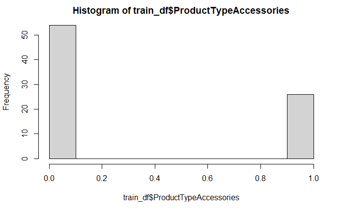

```r
hist(train_df$ProductTypeAccessories)
```

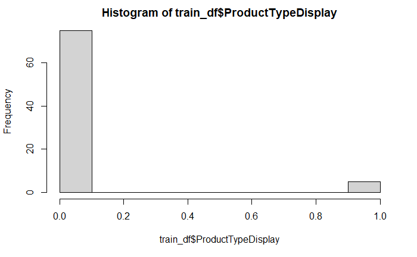

```r
hist(train_df$ProductTypeDisplay)
```

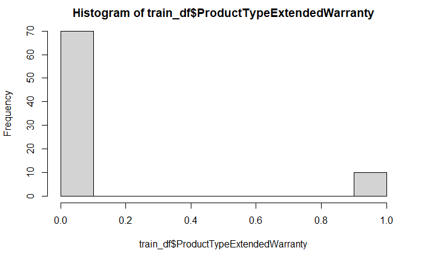

```r
hist(train_df$ProductTypeExtendedWarranty)
```

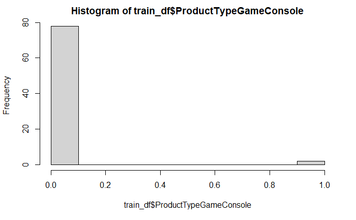

```r
hist(train_df$ProductTypeGameConsole)
```

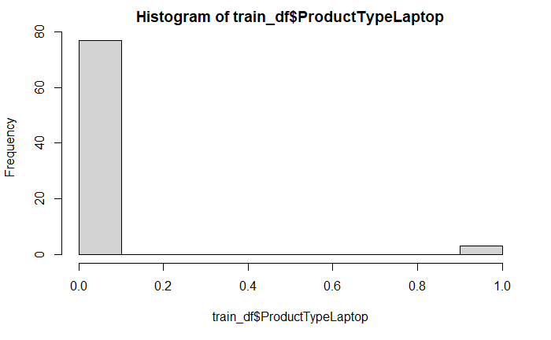

```r
hist(train_df$ProductTypeLaptop)
```

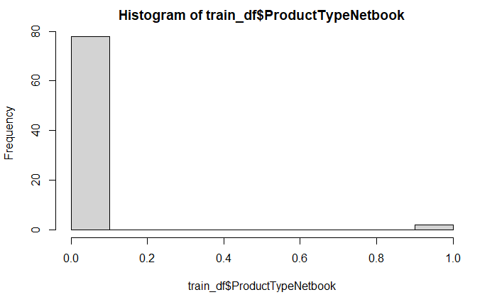

```r
hist(train_df$ProductTypeNetbook)
```

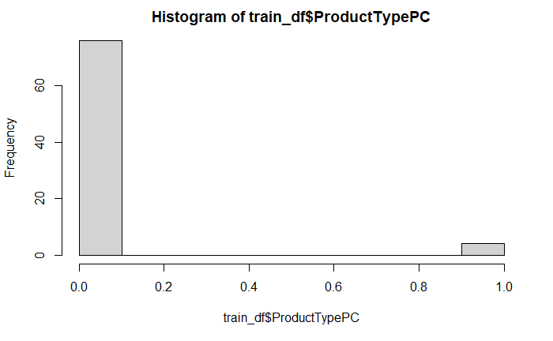

```r
hist(train_df$ProductTypePC)
```

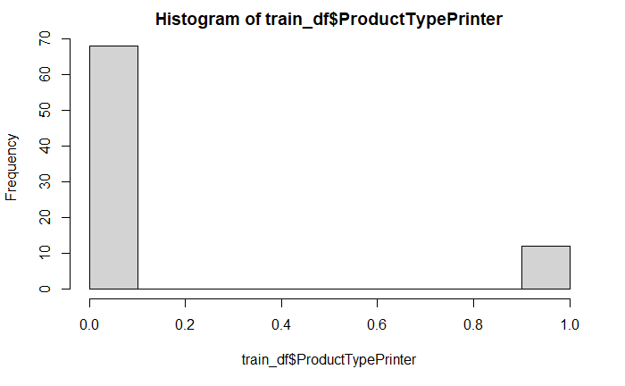

```r
hist(train_df$ProductTypePrinter)
```

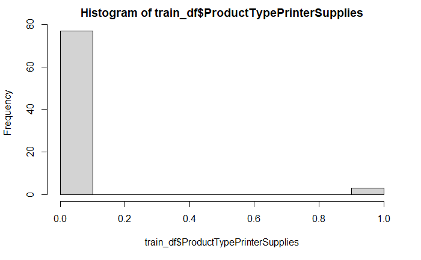

```r
hist(train_df$ProductTypePrinterSupplies)
```

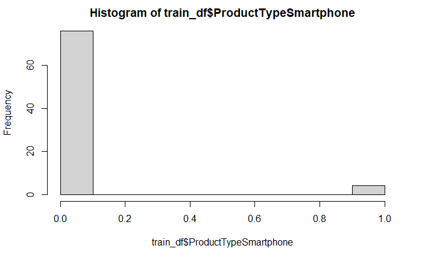

```r
hist(train_df$ProductTypeSmartphone)
```

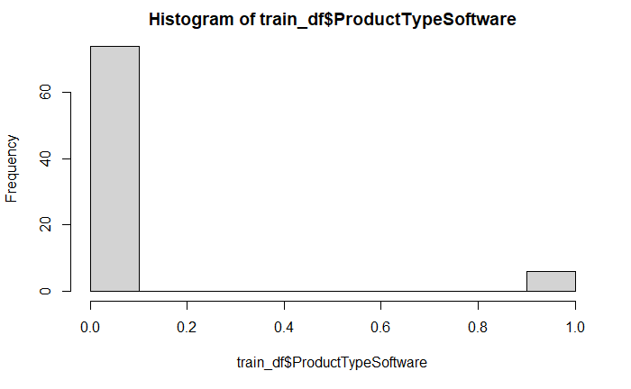

```r
hist(train_df$ProductTypeSoftware)
```

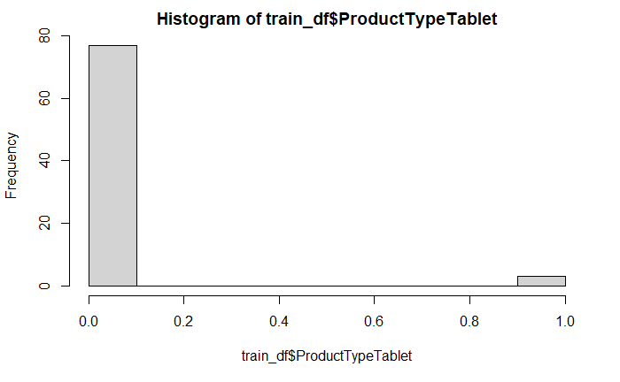

```r
hist(train_df$ProductTypeTablet)
```

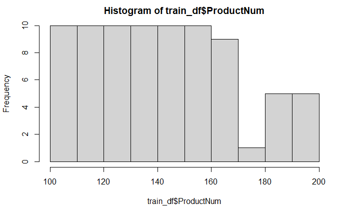

```r
hist(train_df$ProductNum)
```

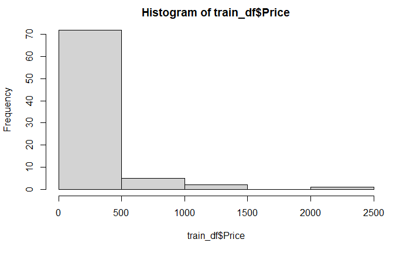

```r
hist(train_df$Price)
```

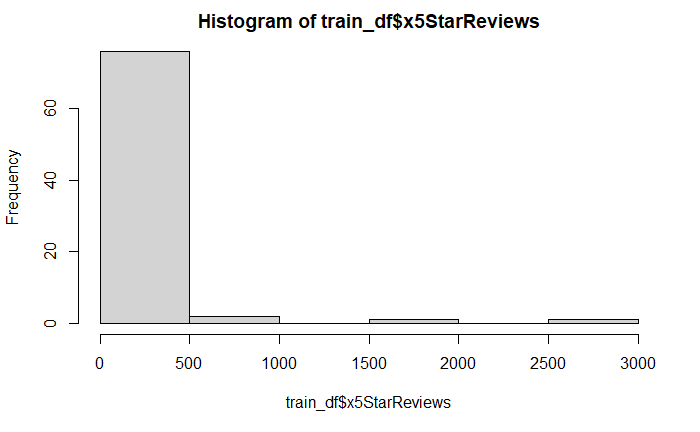

```r
hist(train_df$x5StarReviews)
```

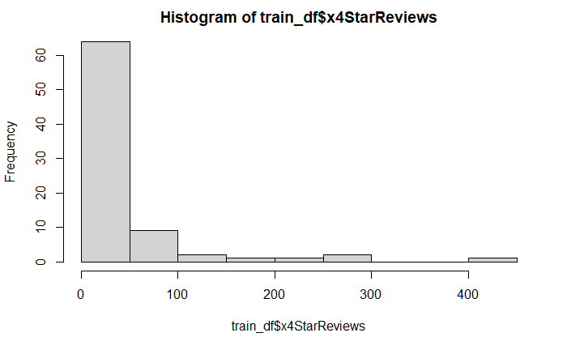

```r
hist(train_df$x4StarReviews)
```

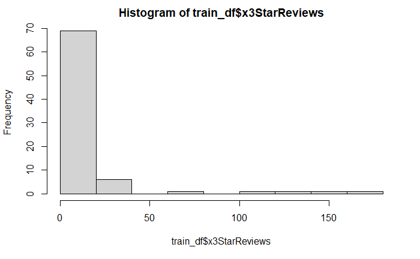

```r
hist(train_df$x3StarReviews)
```

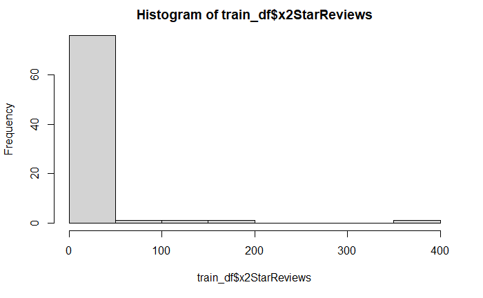

```r
hist(train_df$x2StarReviews)
```

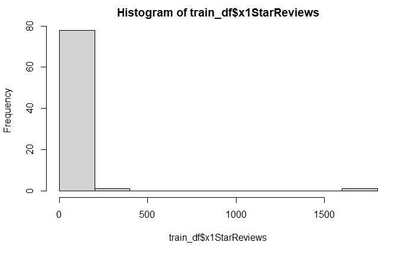

```r
hist(train_df$x1StarReviews)
```

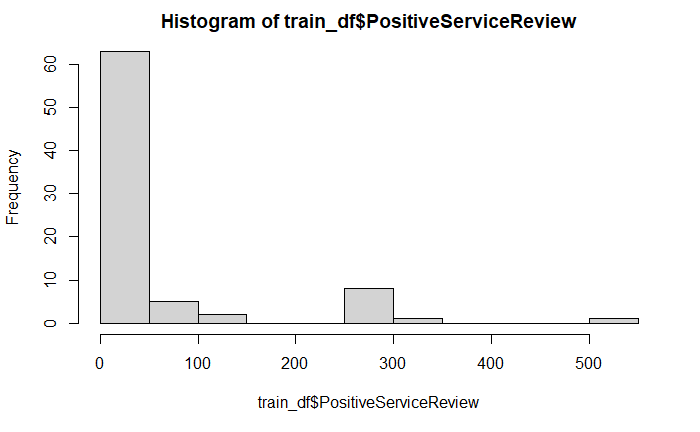

```r
hist(train_df$PositiveServiceReview)
```

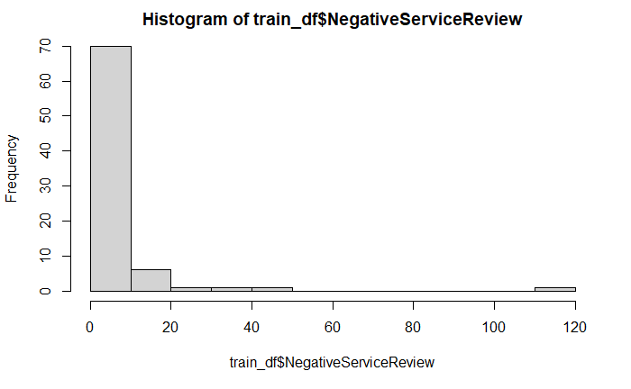

```r
hist(train_df$NegativeServiceReview)
```

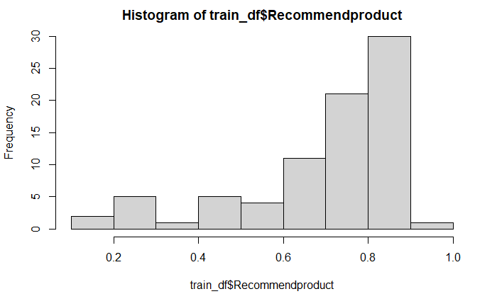

```r
hist(train_df$Recommendproduct)
```

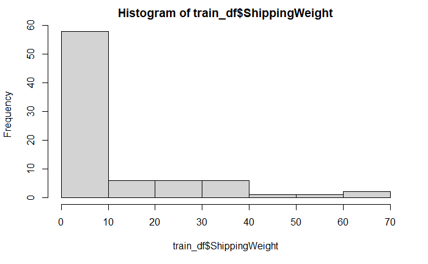

```r
hist(train_df$ShippingWeight)
```

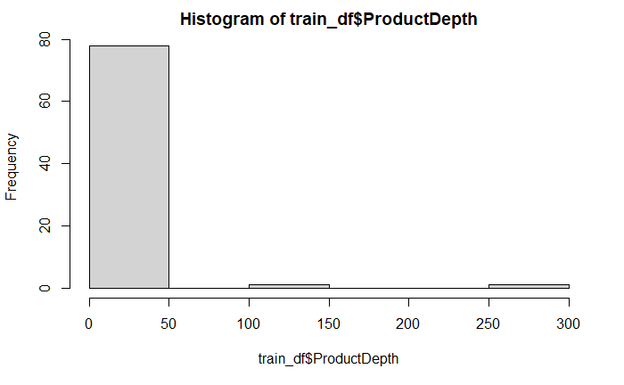

```r
hist(train_df$ProductDepth)
```

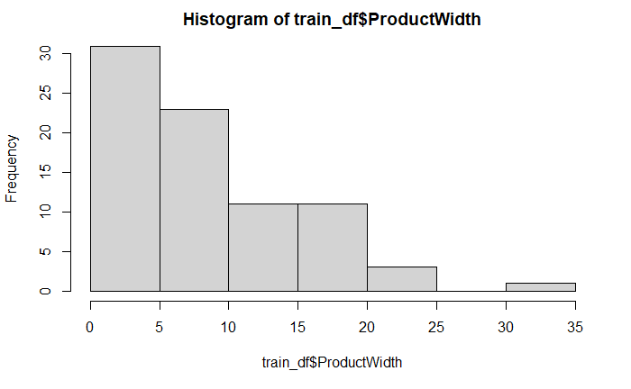

```r
hist(train_df$ProductWidth)
```

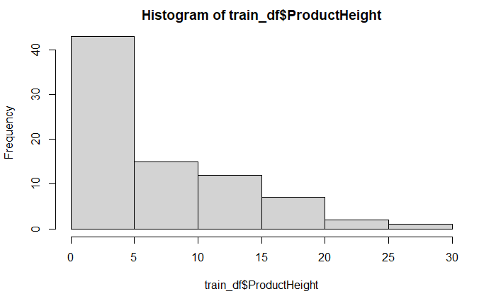

```r
hist(train_df$ProductHeight)
```

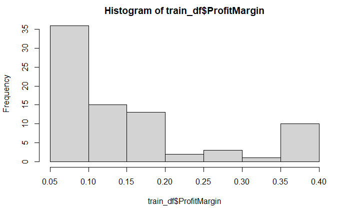

```r
hist(train_df$ProfitMargin)
```

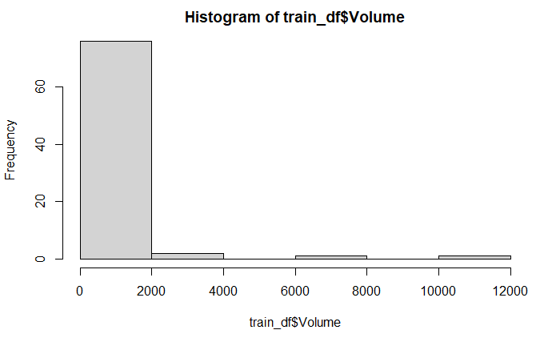

```r
hist(train_df$Volume)
```

Note: Below I created a multiple linear regression (which is not what the PoA asked for, therefore I will not go into much detail other than a brief comment.

```r
#Write trainSet in the data parameter instead of on each variable just to improve readability
MLRModel<- lm(Volume ~ ., training) #Creation of a Multiple Linear Regression taking into account all variables (except obviously for the dependent one) as features to forecast the Volume;
summary(MLRModel)
```

```
essentially perfect fit: summary may be unreliable
```

```
Call:
lm(formula = Volume ~ ., data = training)

Residuals:
       Min         1Q     Median         3Q        Max
-3.375e-12 -1.561e-13  0.000e+00  1.422e-13  1.840e-12

Coefficients: (1 not defined because of singularities)
                              Estimate Std. Error    t value Pr(>|t|)
(Intercept)                  2.196e-12  2.339e-12  9.390e-01   0.3545
ProductTypeAccessories      -2.258e-13  1.046e-12 -2.160e-01   0.8304
ProductTypeDisplay          -1.758e-15  9.266e-13 -2.000e-03   0.9985
ProductTypeExtendedWarranty -2.476e-12  1.858e-12 -1.333e+00   0.1915
ProductTypeGameConsole       1.405e-12  1.298e-12  1.082e+00   0.2867
ProductTypeLaptop           -1.066e-12  1.122e-12 -9.500e-01   0.3487
ProductTypeNetbook           6.548e-13  1.212e-12  5.400e-01   0.5924
ProductTypePC               -4.040e-13  1.280e-12 -3.160e-01   0.7543
ProductTypePrinter           1.137e-12  1.334e-12  8.520e-01   0.4001
ProductTypePrinterSupplies  -1.772e-12  1.556e-12 -1.139e+00   0.2627
ProductTypeSmartphone        1.121e-13  1.077e-12  1.040e-01   0.9177
ProductTypeSoftware         -2.447e-12  1.238e-12 -1.977e+00   0.0562 .
ProductTypeTablet                   NA         NA         NA       NA
ProductNum                  -1.659e-14  1.210e-14 -1.371e+00   0.1793
Price                        6.784e-16  8.011e-16  8.470e-01   0.4031
x5StarReviews                4.000e+00  1.148e-15  3.483e+15   <2e-16 ***
x4StarReviews               -1.823e-14  1.830e-14 -9.960e-01   0.3264
x3StarReviews                3.860e-14  3.234e-14  1.193e+00   0.2409
x2StarReviews                1.201e-14  4.550e-14  2.640e-01   0.7934
x1StarReviews               -1.740e-15  9.336e-15 -1.860e-01   0.8532
PositiveServiceReview        1.684e-16  2.536e-15  6.600e-02   0.9475
NegativeServiceReview       -8.688e-16  3.056e-14 -2.800e-02   0.9775
Recommendproduct             5.062e-13  8.900e-13  5.690e-01   0.5733
ShippingWeight              -1.461e-14  2.359e-14 -6.190e-01   0.5399
ProductDepth                -2.570e-16  3.602e-15 -7.100e-02   0.9435
ProductWidth                -8.145e-14  4.495e-14 -1.812e+00   0.0788 .
ProductHeight                2.285e-15  3.221e-14  7.100e-02   0.9439
ProfitMargin                 4.839e-12  4.798e-12  1.009e+00   0.3203
---
Signif. codes:  0 ‘***’ 0.001 ‘**’ 0.01 ‘*’ 0.05 ‘.’ 0.1 ‘ ’ 1

Residual standard error: 9.02e-13 on 34 degrees of freedom
Multiple R-squared:      1, Adjusted R-squared:      1
F-statistic: 8.249e+30 on 26 and 34 DF,  p-value: < 2.2e-16
```

```r
pred_MLR <- predict(MLRModel, newdata = testing)
```

```
prediction from a rank-deficient fit may be misleading
```

```r
postResample(pred_MLR, testing$Volume)
```

```
        RMSE     Rsquared          MAE
7.929433e-13 1.000000e+00 5.567944e-13
```

The multiple linear regression obtained incredible results which is doubtful. Something could be wrong above. If all is correct then the dependent variable is extremely predictable looking into the independent ones. I will confirm this in the following models.

*Let’s dive into some non-parametric machine learning models now:*

**Caret Model 2: Support Vector Machine (SVM)**

```r
svmfitControl <- trainControl(method = "repeatedcv",
                              number = 10, # number of folds
                              repeats = 1) #the number of complete sets of folds to compute
```

In order to choose the optimization metric: -Both RMSE and R2 quantify how well a regression model fits a dataset. -The RMSE tells us how well a regression model can predict the value of the response variable in absolute terms while R2 tells us how well a model can predict the value of the response variable in percentage terms.

Therefore, I will use the RMSE metric as the point of this regression is to forecast the absolute Volume as accurately as possible (also the results were better utilizing this metric).

```r
svmFit1 <- train(Volume~., #y, target
                data = training,#X, features
                metric = 'RMSE', #Metric applied
                method = "svmLinear", #ML algorithm
                trControl=svmfitControl,  #Apply CV to the training
                tuneGrid = expand.grid(C=3**(-7:7)),
                verbose = FALSE)
```

[output not shown]

```r
svmFit1
```

```
Support Vector Machines with Linear Kernel

61 samples
27 predictors

No pre-processing
Resampling: Cross-Validated (10 fold, repeated 1 times)
Summary of sample sizes: 55, 57, 55, 54, 54, 55, ...
Resampling results across tuning parameters:

  C             RMSE      Rsquared   MAE
  4.572474e-04  721.6265  0.8649201  451.8292
  1.371742e-03  588.6928  0.8928494  380.9913
  4.115226e-03  544.2343  0.9003890  326.2890
  1.234568e-02  483.9296  0.9436916  280.6139
  3.703704e-02  574.4111  0.9483015  301.1606
  1.111111e-01  440.1400  0.9467436  257.5161
  3.333333e-01  361.1476  0.9147411  216.3648
  1.000000e+00  361.1476  0.9147411  216.3648
  3.000000e+00  361.1476  0.9147411  216.3648
  9.000000e+00  361.1476  0.9147411  216.3648
  2.700000e+01  361.1476  0.9147411  216.3648
  8.100000e+01  361.1476  0.9147411  216.3648
  2.430000e+02  361.1476  0.9147411  216.3648
  7.290000e+02  361.1476  0.9147411  216.3648
  2.187000e+03  361.1476  0.9147411  216.3648

RMSE was used to select the optimal model using the smallest value.
The final value used for the model was C = 0.3333333.
```

Train function chooses the model with the largest performance value (or smallest, for mean squared error in regression models), therefore there is no need to select the best iteration of the models.

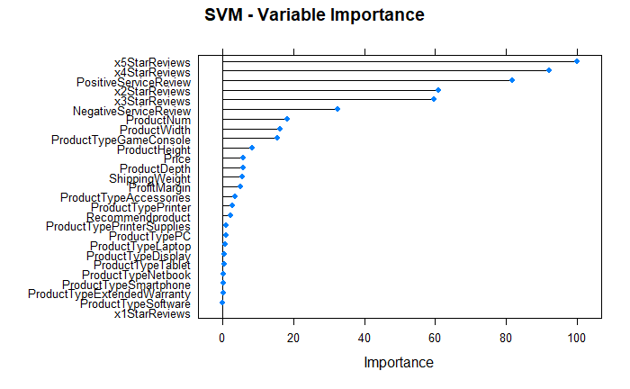

As was predicted in the correlation section, the Review variables are the most relevant towards forecasting this target.

```r
pred_SVM <- predict(svmFit1, newdata = testing)

Pred_Value_SVM <- predict(svmFit1, newdata = testing)

postResample(pred_SVM, testing$Volume)
```

```
       RMSE    Rsquared         MAE
156.3079599   0.9326557 127.3560858
```

For the testing portion of the train_df: The value of the Root Mean Squared Error is ~156, taking into account that the average Volume is 700, this error is not terrible, but it is not great as well. The same goes for a Mean Absolute Error of ~127. The rsquared is ~0.93 which means that this models is an alright fit for this task.

**Caret Model 3: Random Forest (RF)**

```r
rffitControl <- trainControl(method = "repeatedcv",
                              number = 10, # number of folds
                              repeats = 1) #the number of complete sets of folds to compute
```

As asked, in this part we are supposed to train a model using Random Forest, RF, on the training set without overfitting. I decided to use 10-fold cross-validation and an Automatic Tuning Grid, which is what is coded below.

I will use the RMSE metric for the same reasons as expressed above.

```r
rfFit1 <- train(Volume~., #y, target
                data = training,#X, features
                metric = 'RMSE', #Metric applied
                method = "rf", #ML algorithm
                trControl=rffitControl, #Apply CV to the training
                tuneLength=100, # Number of levels for each tuning parameters that should be generated
                verbose = FALSE)
rfFit1
```

```
Random Forest

61 samples
27 predictors

No pre-processing
Resampling: Cross-Validated (10 fold, repeated 1 times)
Summary of sample sizes: 56, 56, 54, 56, 54, 54, ...
Resampling results across tuning parameters:

  mtry  RMSE      Rsquared   MAE
   2    828.9000  0.8953433  460.4654
   3    791.4409  0.8900860  424.6805
   4    800.1808  0.8989770  401.5774
   5    782.1180  0.9102185  377.3093
```

[output cut: 25 more lines]

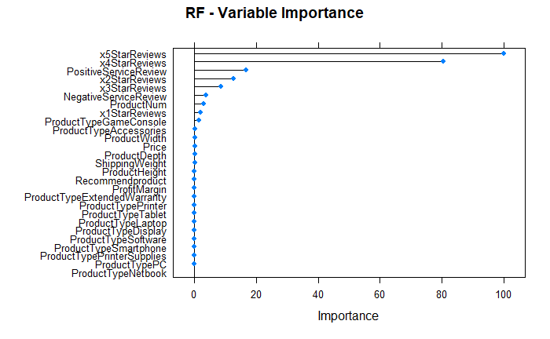

Similarly to the previous model, the most relevant features are by far the ones associated with reviews (as predicted).

```r
pred_RF <- predict(rfFit1, newdata = testing)

Pred_Value_RF <- predict(rfFit1, newdata = testing)

postResample(pred_RF, testing$Volume)
```

```
      RMSE   Rsquared        MAE
53.3563808  0.9933894 30.2465895
```

**Caret Model 4: Gradient Boosting (GB)**

```r
gbmfitControl <- trainControl(method = "repeatedcv",
                              number = 10, # number of folds
                              repeats = 1) #the number of complete sets of folds to compute
```

As asked, in this part we are supposed to train a model using Gradient Boosting, GBM, on the training set without overfitting. I decided to use 10-fold cross-validation and an Automatic Tuning Grid, which is what is coded below.